# Statistical inference with the GSS data

## Setup

### Load packages

```r
library(ggplot2)
library(dplyr)
library(statsr)
```

### Load data

```r
load("gss.Rdata")
```

### Dataset Discription

**Data:** Data is from General Social Survey(GSS) for a sampled population which shows the trend in attitudes, behavirs and attributes on contemporary Americans society. Purpose of this survey to examine th structure and functioning of society in general. Also, to compare American Society with other society and develop cross-national models of human society.

**Data Collection and Implication:** Survey is conducted mainly by random Sampling. Thus, we can generalize the result using Infrential Statistics tools. There is no random assignment hence no causal relation can be established.

## Part 2: Research question

### Research Question

**Question:** We want to answer if there is any relationship between How often does people read newspaper and their age group. Our focus area will be two age group Young(25-50) and old(50-75).

We will create new variable Age_Group_Type, which have two categorical variables:

- Young (which has age between 25-50, 25 and 50 both included)
- Old (Which has age between 50-75, 50 excluded but 75 included)

**Motivation:** There is a preconceived notion that as aged people reads newspaper frequently compared to the young people. We want to confirm whether it is true or not based on data.

## Part 3: Exploratory data analysis

### Data Cleaning

Our variables of interst are column(age) and column(news). So, lets first remove the NA’s values from both the columns and subset only those rows which has age between 25 and 75. Then add a new column Age_Group_Type having two levels : “Young” and“Old”. For safer side, Also convert column(news) and convert column(Age_Group_Type) as factors if R is considering these columns as Character.

```r
data <- gss[which(is.na(gss$age) == FALSE), ]
data <- data[which(is.na(data$news) == FALSE),]
data <- data[which(data$age >= 25 & data$age <= 75), ]
data$Age_Group_Type <- ifelse(data$age <= 50, "Young", "Old")
data$Age_Group_Type <- as.factor(data$Age_Group_Type)
data$news <- as.factor(data$news)
```

### Data Exploration

Summary of Age_Group_Type and News.

```r
summary(data$Age_Group_Type)
```

```
##   Old Young
## 10831 18789
```

```r
summary(data$news)
```

```
##          Everyday  Few Times A Week       Once A Week Less Than Once Wk
##             14518              6251              3803              2863
##             Never
##              2185
```

Lets make the contigency table for Age_Group_Type and News.

```r
table(data$Age_Group_Type, data$news)
```

```
##
##         Everyday Few Times A Week Once A Week Less Than Once Wk Never
##   Old       6705             1589        1009               685   843
##   Young     7813             4662        2794              2178  1342
```

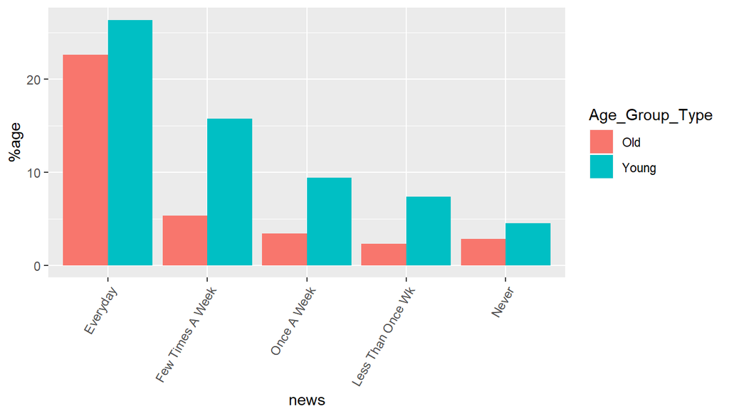

```r
ggplot(data = data, aes(x=news, fill = Age_Group_Type)) + geom_bar( aes(y = ..count.. * 100/sum(..count..)), position = position_dodge()) + ylab("%age") + theme(axis.text.x = element_text(angle=60,hjust = 1))
```

**Observation:**

- There is a significant differnce between the young and old people those who reads news few times a week, once a week and less than a week. We have check whether there is also significant difference in the whole population or not.

## Part 4: Inference

As the both variables of interest are Categorical Variable and one of them (news) have more than two levels. So, we will perform **Chi-Squared Independence Test**.

##### **Step-1: State the Hypotheses**

- **Null Hypothesis:** News reading and Age are independent. Reading newspaper frequency doesn’t vary with aging.
- **Alternate Hypothesis:** News reading and Age are dependent. Reading newspaper frequency vary with aging.

##### **Step-2: Check the Conditions**

1. **Independence**
   - Random Sample/Assignment: As it is already mentioned in the survey was generated by random sampling.
   - Also, as the survey is sampling without replacement so the condition n < 10% of population also met. As sampled observations are 29620(after removing NA), which is obviously less than the whole American population.
2. **Sample Size:** Expected count for each cell must be atleast 5 for each cell. Lets check that!

```r
chisq.test(data$Age_Group_Type, data$news)$expected
```

```
##                    data$news
## data$Age_Group_Type Everyday Few Times A Week Once A Week
##               Old   5308.726         2285.772    1390.624
##               Young 9209.274         3965.228    2412.376
##                    data$news
## data$Age_Group_Type Less Than Once Wk     Never
##               Old            1046.899  798.9782
##               Young          1816.101 1386.0218
```

From the above table, clearly every cell has an expected count more than 5. We’re now all clear to perform chi-squared test of independence!

##### **Step-3: Degree of Freedom**

We have 2 age group and 5 News reading frequency level.

Hence, **df** **:** **(2-1)X(5-1)** **=** **4**

##### **Step-4: Chi-Squared test of independence**

```r
chisq.test(data$news,data$Age_Group_Type)
```

```
##
##  Pearson's Chi-squared test
##
## data:  data$news and data$Age_Group_Type
## X-squared = 1279.9, df = 4, p-value < 2.2e-16
```

The chi-squared statistic is 1279.9 and the corresponding p-value for 4 degrees of freedom is much lower than the significance level of 0.05. Hence, we reject the Null Hypothesis.

Therfore, **Age and Frequency of reading newspaper is dependent on each other.**